# Mia_Dust_FunGuilds

Nat Pombubpa

Updated on October 19, 2018

### STEP1: Load all necessary packages for analysis

More information about Phyloseq can be found at the following link: [Phyloseq](https://joey711.github.io/phyloseq/) If you get error in this step, you probably need to install any packages which causes error.

```r
library(ape)
library(vegan)
library(dplyr)
library(scales)
library(grid)
library(reshape2)
library(phyloseq)
library(magrittr)
library(ggplot2)
library(ggpubr)
library(plyr)
```

### STEP2: Import Mapping file (metadate file)

1.Check mapping file before import to R, R will automatically change sample name that starts with number or contain “-” in sample name. If you get error in this step, you should check sample name first.

2.First column of first row should not start with #, R will not read the first row that starts with #

3.Please make sure that your metadata and FunGuilds SampleID are the same.

```r
meta = read.table("SierraMapIsoF.csv",header=TRUE,row.names=1,sep=",",stringsAsFactors=FALSE)
```

### STEP3: Check if your metadata file has been import successfully and correctly

The output will show a table of your metadata file (mapping file).

*If you do not have header, you might start your first row with #

```r
head(meta)
```

```
##       BarcodeSequence LinkerPrimerSequence Year  NdEp       Sr  Month
## AJ414              NA                   NA  one -3.97 0.708101 August
## AP114              NA                   NA  one -4.30 0.708349 August
## AS114              NA                   NA  one -4.57 0.709982 August
## AT414              NA                   NA  one -3.95 0.708165 August
## JJ114              NA                   NA  one -3.98 0.708293   July
## JJ415              NA                   NA  two -4.10 0.707771   July
##       SiteCode RepNum SiteRep       Site Elevation DateCode DescName
## AJ414        J      4      J4       SJER       400        B    AJ414
## AP114        P      1      P1 PROVIDENCE      2000        B    AP114
## AS114        S      1      S1  SHORTHAIR      2700        B    AS114
## AT414        T      4      T4   SOAPROOT      1100        B    AT414
## JJ114        J      1      J1       SJER       400        A    JJ114
## JJ415        J      4      J4       SJER       400        A    JJ415
##       Description
## AJ414      BAJ414
## AP114      BAP114
## AS114      BAS114
## AT414      BAT414
## JJ114      AJJ114
## JJ415      AJJ415
```

```r
dim(meta)
```

```
## [1] 31 14
```

### STEP4: Construct sample_data-class using imported metadata

```r
sampleData <- sample_data(meta)
```

### STEP5: Import FunGuilds table

FunGuilds table from Dust data is “DustFungi.guilds.txt”. This is otu table which also includes Taxon,Trophic Mode, Guild, Growth Morphology etc.) ‘FG’ contains the entire table, but ‘FGotus’ is used to select only the otu table part from FunGuilds table (abundance + OTU ID)

```r
FG <- read.table("DustFungi.guilds.txt",header=T,sep="\t",row.names=1)
FGotus <- select(FG, -(Taxonomy:Citation.Source))
FGotumat <- as(as.matrix(FGotus), "matrix")
FGOTU = otu_table(FGotumat, taxa_are_rows = TRUE)
```

Entire Data from FunGuilds table (first 6 lines)

```r
head(FG)
```

```
##      AJ414 AP114 AS114 AT414 JJ114 JJ415 JJ515 JP315 JP414 JP515 JS115
## OTU1  9461  5607 11584  1649     0     0    92   769   787 10086  8432
## OTU2   896  1657   369  1562 14487  9623  5486  7095 11540  3649   503
## OTU4 19126  6478  7139   402  1848   655   689  1057   187   325  1138
## OTU3   911  1434  5753  2653    77    35    21   417    75     0  2432
## OTU5     0  9025     0  2163     0     0    47   745  3628   581     0
## OTU7   345   774     0  2714   524   904   717   312   553   353    70
##      JS415 JT115 JT314 JT415 OJ415 OJ514 OJ515 OJ615 OP315 OP515 OP614
## OTU1  6952     0  1258   182     0     0   136   202  2765 15177  5679
## OTU2  1073  2028  5772   455  1366  1870  1432  1233  5856  6878   258
## OTU4  1349   592   610   852   579  1971   589   225  1140  1063   117
## OTU3   523     0  1232     0   193   481   237  1213  2056    44 11699
## OTU5    28  1598  1104   514     0     0     0     0   236   454 16551
## OTU7   192   395  2324    99  3183  3259  3634  1865   180  1021    73
##      OP615 OS115 OS214 OS415 OS615 OT115 OT414 OT415 OT515
## OTU1  2264 12199  4225  7247 27541  6461 34777  4072  3570
## OTU2  6433  1628  1654  4132   116  1248   618  1895  2053
## OTU4   520  4892 12755  5460    53   677   228   195  2566
## OTU3   607  1868    87   289     0   133 13287  2092   183
## OTU5   680     0   421    82     0   176  5902   202   209
## OTU7   967   138    94   395     0  1765  1087  3104  1064
##                                                                                                                        Taxonomy
## OTU1 GSL|100.0|KF861805|SH206550.07FU;k:Fungi,p:Basidiomycota,c:Tremellomycetes,o:Filobasidiales,f:Filobasidiaceae,g:Naganishia
## OTU2                                                                                   GDL|100.0|HM999854|SH207241.07FU;k:Fungi
## OTU4                                      GSL|100.0|KT693613|SH195774.07FU;k:Fungi,p:Ascomycota,c:Dothideomycetes,o:Dothideales
## OTU3                                                   GS|99.4|MF533187|SH220112.07FU;k:Fungi,p:Basidiomycota,c:Tremellomycetes
## OTU5                      GS|99.6|FJ553309|SH196149.07FU;k:Fungi,p:Ascomycota,c:Eurotiomycetes,o:Chaetothyriales,g:Sarcinomyces
## OTU7                     GSL|100.0|KC253942|SH215493.07FU;k:Fungi,p:Ascomycota,c:Dothideomycetes,o:Pleosporales,f:Pleosporaceae
##              Taxon Taxon.Level          Trophic.Mode
## OTU1             -           -                     -
## OTU2             -           -                     -
## OTU4             -           -                     -
## OTU3             -           -                     -
## OTU5             -           -                     -
## OTU7 Pleosporaceae           9 Pathotroph-Saprotroph
##                                                              Guild
## OTU1                                                             -
## OTU2                                                             -
## OTU4                                                             -
## OTU3                                                             -
```

[output cut: 8 more lines]

```
## OTU7           Probable       Microfungus  NULL
##                                                                                                                          Notes
## OTU1                                                                                                                Unassigned
## OTU2                                                                                                                Unassigned
## OTU4                                                                                                                Unassigned
## OTU3                                                                                                                Unassigned
## OTU5                                                                                                                Unassigned
## OTU7 Necrotrophic pathogens and saprobes, especially associated with grasses. Many species are seed-borne (Cannon & Kirk 2007)
##                                                                                                                                                                                                               Citation.Source
## OTU1                                                                                                                                                                                                                        -
## OTU2                                                                                                                                                                                                                        -
## OTU4                                                                                                                                                                                                                        -
## OTU3                                                                                                                                                                                                                        -
## OTU5                                                                                                                                                                                                                        -
## OTU7 Cannon PF, Kirk PM. 2007. Fungal Families of the World. CAB International, Cambridge; David AS, et al. 2016. Microbial Ecology 71:912-926; Lawrey JD, Diederich P. 2016. URL: http://www.lichenicolous.net [24 May 2017]
```

```r
dim(FG)
```

```
## [1] 2180   41
```

Selcted Data from FunGuilds table (first 6 lines)

```r
head(FGOTU)
```

```
## OTU Table:          [6 taxa and 31 samples]
##                      taxa are rows
##      AJ414 AP114 AS114 AT414 JJ114 JJ415 JJ515 JP315 JP414 JP515 JS115
## OTU1  9461  5607 11584  1649     0     0    92   769   787 10086  8432
## OTU2   896  1657   369  1562 14487  9623  5486  7095 11540  3649   503
## OTU4 19126  6478  7139   402  1848   655   689  1057   187   325  1138
## OTU3   911  1434  5753  2653    77    35    21   417    75     0  2432
## OTU5     0  9025     0  2163     0     0    47   745  3628   581     0
## OTU7   345   774     0  2714   524   904   717   312   553   353    70
##      JS415 JT115 JT314 JT415 OJ415 OJ514 OJ515 OJ615 OP315 OP515 OP614
## OTU1  6952     0  1258   182     0     0   136   202  2765 15177  5679
## OTU2  1073  2028  5772   455  1366  1870  1432  1233  5856  6878   258
## OTU4  1349   592   610   852   579  1971   589   225  1140  1063   117
## OTU3   523     0  1232     0   193   481   237  1213  2056    44 11699
## OTU5    28  1598  1104   514     0     0     0     0   236   454 16551
## OTU7   192   395  2324    99  3183  3259  3634  1865   180  1021    73
##      OP615 OS115 OS214 OS415 OS615 OT115 OT414 OT415 OT515
## OTU1  2264 12199  4225  7247 27541  6461 34777  4072  3570
## OTU2  6433  1628  1654  4132   116  1248   618  1895  2053
## OTU4   520  4892 12755  5460    53   677   228   195  2566
## OTU3   607  1868    87   289     0   133 13287  2092   183
## OTU5   680     0   421    82     0   176  5902   202   209
## OTU7   967   138    94   395     0  1765  1087  3104  1064
```

```r
dim(FGOTU)
```

```
## [1] 2180   31
```

### STEP6: Import Functional Guilds (Trophic Mode, Guild, Growth.Morphology) as Taxonomy feature

```r
FGtaxmat <- select(FG, Confidence.Ranking, Trophic.Mode, Guild, Growth.Morphology, Taxon)
FGtaxmat <- as(as.matrix(FGtaxmat),"matrix")
FGTAX = tax_table(FGtaxmat)
```

```r
head(FGTAX)
```

```
## Taxonomy Table:     [6 taxa by 5 taxonomic ranks]:
##      Confidence.Ranking Trophic.Mode
## OTU1 "-"                "-"
## OTU2 "-"                "-"
## OTU4 "-"                "-"
## OTU3 "-"                "-"
## OTU5 "-"                "-"
## OTU7 "Probable"         "Pathotroph-Saprotroph"
##      Guild
## OTU1 "-"
## OTU2 "-"
## OTU4 "-"
## OTU3 "-"
## OTU5 "-"
## OTU7 "Endophyte-Lichen Parasite-Plant Pathogen-Undefined Saprotroph"
##      Growth.Morphology Taxon
## OTU1 "-"               "-"
## OTU2 "-"               "-"
## OTU4 "-"               "-"
## OTU3 "-"               "-"
## OTU5 "-"               "-"
## OTU7 "Microfungus"     "Pleosporaceae"
```

### STEP7: Construct Phyloseq object

To construct phyloseq object, otu table, taxonomy table, and sampleData are required.

```r
fgps = phyloseq(FGOTU,FGTAX,sampleData)
```

Check phyloseq object

```r
fgps
```

```
## phyloseq-class experiment-level object
## otu_table()   OTU Table:         [ 2180 taxa and 31 samples ]
## sample_data() Sample Data:       [ 31 samples by 14 sample variables ]
## tax_table()   Taxonomy Table:    [ 2180 taxa by 5 taxonomic ranks ]
```

### STEP8: Filtering FunGuilds Data

Note: you might want to check the entire data before you use these filters.

```r
fgps.prune = prune_taxa(taxa_sums(fgps) > 10, fgps)
#fgps.prune.confidence1 = subset_taxa(fgps.prune, Confidence.Ranking!="Possible")
fgps.prune.no.na = subset_taxa(fgps.prune, Trophic.Mode!="-")
#fgps.prune.no.null = subset_taxa(fgps.prune.no.na, Guild!="NULL")
#fgps.prune.no.null = subset_taxa(fgps.prune.no.null, Growth.Morphology!="NULL")
```

Check phyloseq object after filtering

```r
fgps.prune.no.na
```

```
## phyloseq-class experiment-level object
## otu_table()   OTU Table:         [ 417 taxa and 31 samples ]
## sample_data() Sample Data:       [ 31 samples by 14 sample variables ]
## tax_table()   Taxonomy Table:    [ 417 taxa by 5 taxonomic ranks ]
```

### STEP9: Plot all FunGuilds data from Trophic.Mode, Guild, Growth.Morphology

x = any environmental variable (in this case, I tested with Site) fill = Functional Guilds that you want to plot (Trophic.Mode, Guild, Growth.Morphology)

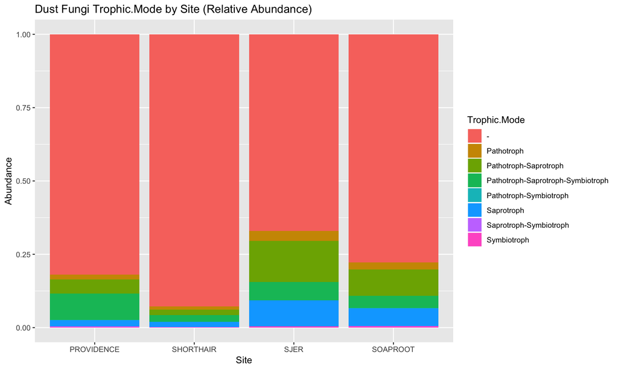

```r
ggplot(data = psmelt(fgps.prune), mapping = aes_string(x = "Site" ,y = "Abundance",
                                                               fill = "Trophic.Mode" )) +
  geom_bar(stat="identity", position="fill") + ggtitle("Dust Fungi Trophic.Mode by Site (Relative Abundance)")
```

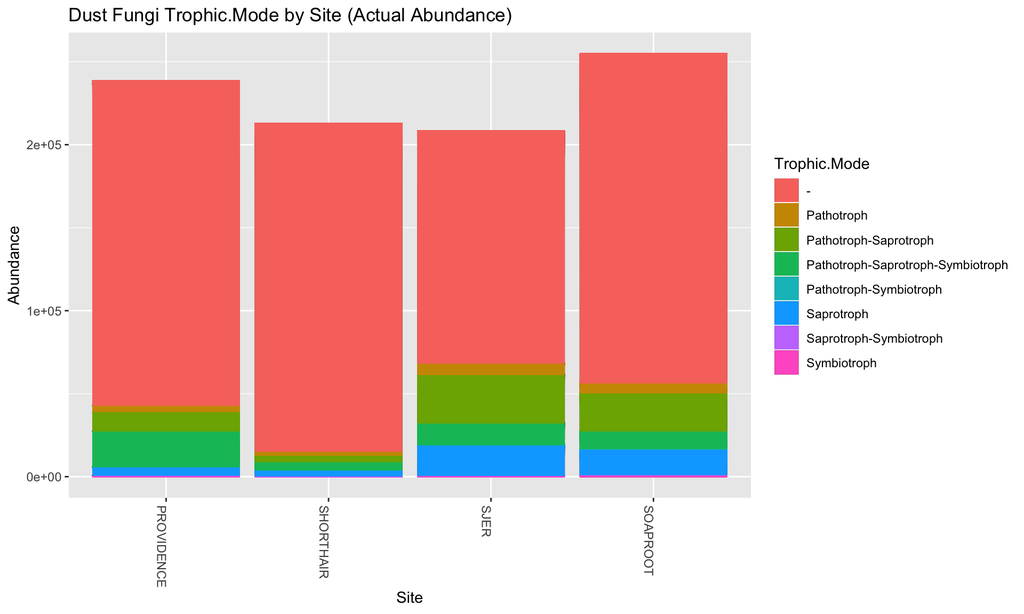

```r
plot_bar(fgps.prune, x="Site",fill = "Trophic.Mode") +
  ggtitle("Dust Fungi Trophic.Mode by Site (Actual Abundance)") +
  geom_bar(aes(color=Trophic.Mode, fill=Trophic.Mode), stat="identity", position="stack")
```

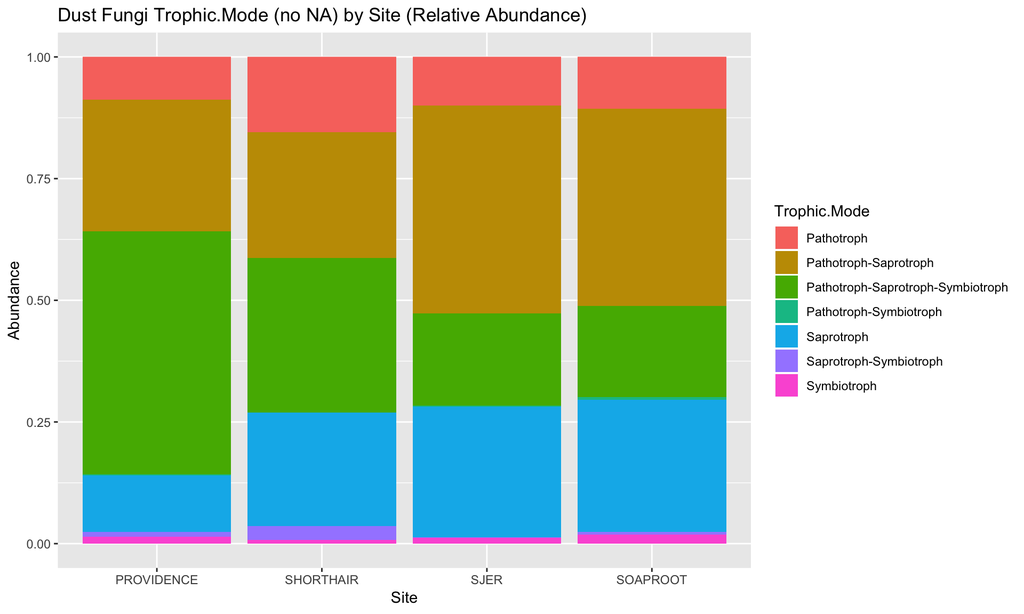

```r
ggplot(data = psmelt(fgps.prune.no.na), mapping = aes_string(x = "Site" ,y = "Abundance",
                                                               fill = "Trophic.Mode" )) +
  geom_bar(stat="identity", position="fill") +
  ggtitle("Dust Fungi Trophic.Mode (no NA) by Site (Relative Abundance)")
```

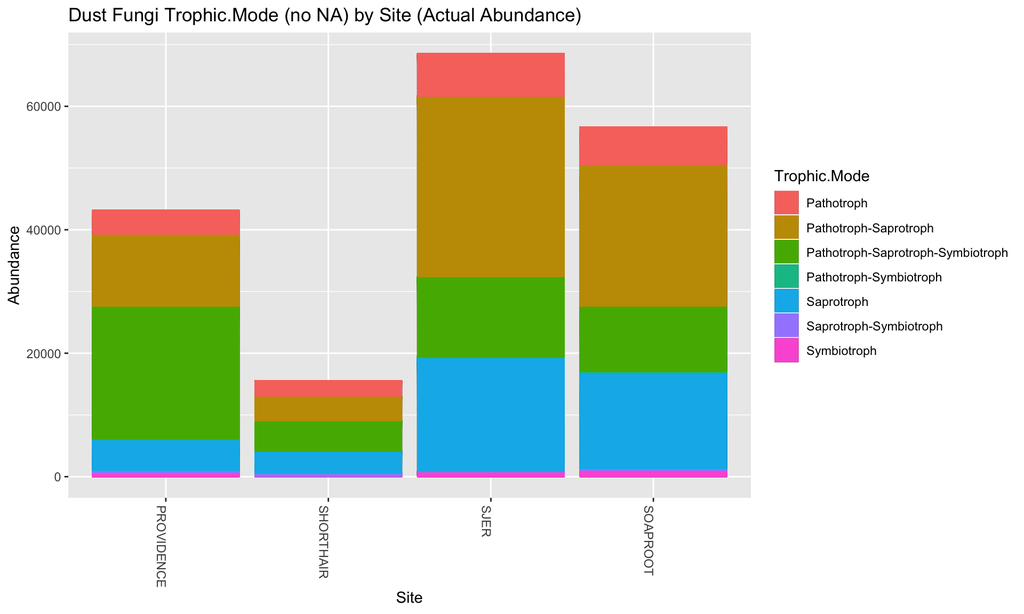

```r
plot_bar(fgps.prune.no.na, x="Site",fill = "Trophic.Mode") +
  ggtitle("Dust Fungi Trophic.Mode (no NA) by Site (Actual Abundance)") +
  geom_bar(aes(color=Trophic.Mode, fill=Trophic.Mode), stat="identity", position="stack")
```

### STEP10: Get the top 50 OTUs and plot only the top abundance

```r
ps.prune = prune_taxa(names(sort(taxa_sums(fgps.prune), TRUE))[1:50], fgps.prune)
```

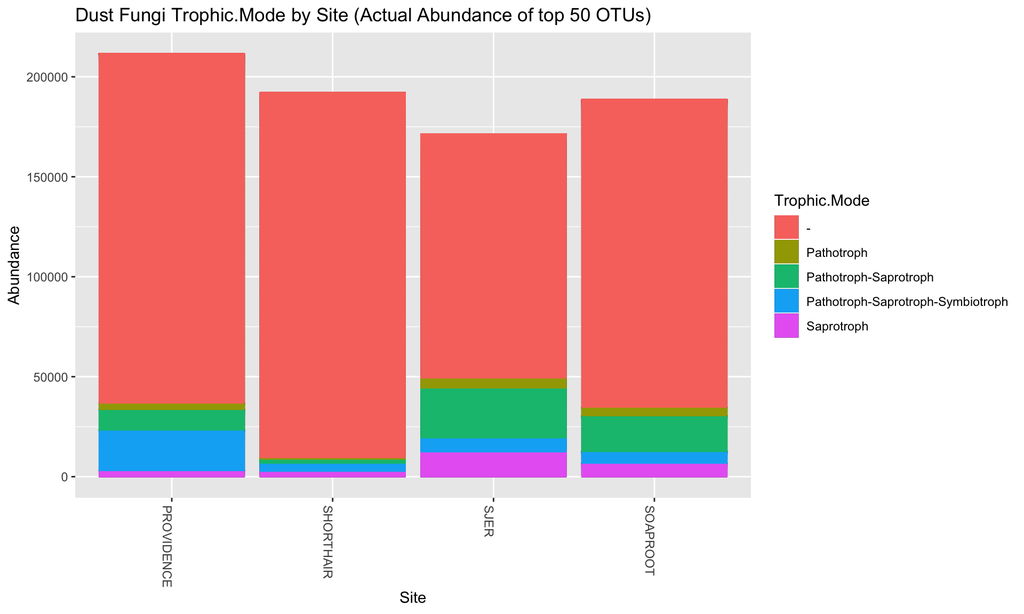

```r
plot_bar(ps.prune, x="Site",fill = "Trophic.Mode") +
  ggtitle("Dust Fungi Trophic.Mode by Site (Actual Abundance of top 50 OTUs)") +
  geom_bar(aes(color=Trophic.Mode, fill=Trophic.Mode), stat="identity", position="stack")
```

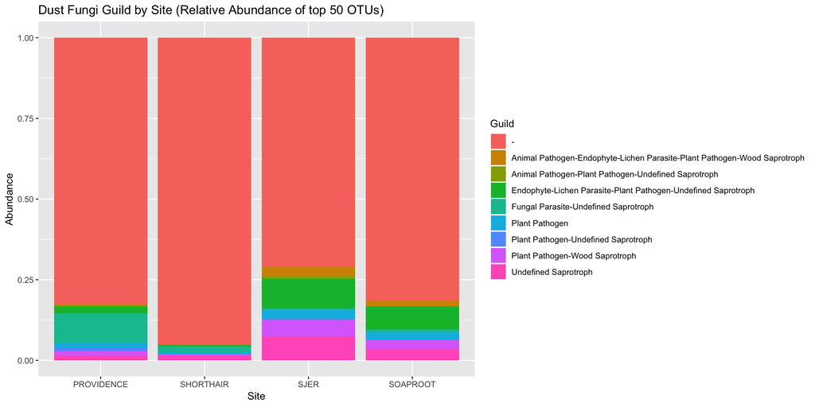

```r
ggplot(data = psmelt(ps.prune), mapping = aes_string(x = "Site" ,y = "Abundance", fill = "Guild" )) +
  geom_bar(stat="identity", position="fill") +
  ggtitle("Dust Fungi Guild by Site (Relative Abundance of top 50 OTUs)")
```